# Lab-P1: Running Programs and Writing Code

Welcome to your first lab! Please follow through the exercises during lab time and ask any questions you have as you go. These will help you solify lecture concepts and prepare you for doing projects.

In terms of ordering, be sure to complete lecture videos for a day before starting a lab on that day, and don’t start a project until completing the corresponding lab.

# Part 1: Running Programs

## Download Your First Program

The first thing you’re going to need to decide is where to keep your work this semester. If you don’t have a preference, we recommend creating a folder named “cs220” under “Documents”. How to find the Documents folder may vary from computer to computer. On a Windows machine, you might find it like this in File Explorer:

[figure not shown]

On a Mac, you might find it in Finder here:

[figure not shown]

Inside the new “cs220” folder you created under “Documents”, we recommend you create a sub-folder called “lab1” and use it for all your files related to this lab.

Download hello.py to your lab1 folder.

## Run Your First Program

Now it gets a little tricky. You need to figure out the path of your “lab1” folder. You can think of a “path” as just a more complete name for a file or folder.

1. open your `Documents` in either File Explorer or Finder
2. copy the pathname of `lab1` using either these [Windows directions](https://www.pcworld.com/article/251406/windows_tips_copy_a_file_path_show_or_hide_extensions.html) or [Mac directions](http://osxdaily.com/2015/11/05/copy-file-path-name-text-mac-os-x-finder/)
3. paste the pathname of `lab1` in your notes somewhere

Now, you’ll need to open something called a “terminal emulator”.

**Windows**: 1. hit the Windows logo key on your keyboard 2. type “powershell” 3. open “Windows PowerShell” (be careful, DO NOT choose the ones that say “ISE” or “x86”)

**Mac**: 1. open Finder 2. click “Applications” 3. open “Utilities” 4. double-click Terminal.app

OK, now the directions are the same for Mac and Windows again. Type this in the terminal (replace `LAB1-PATH` with the pathname of `lab1`, as you determined above; keep the quotes around the pathname, though) and hit enter:

```
cd "LAB1-PATH"
```

Type `ls` (that’s the letter, not a one) and hit enter. If you’ve done everything correctly so far, you should see the “hello.py” file that you downloaded in step 1 listed.

Now, type `python hello.py` and hit ENTER. Note that you may need to instead type `python3 hello.py`, depending on your setup (on most Mac setups, you’ll be typing python3). If everything is working correctly, you should see the following message printed:

```
Hello, World!
```

Congrats! The above is the trickiest part of the lab.

## Reading Code

Before we move onto the next program, type `cat hello.py` and hit ENTER. You should see the following:

```python
print("Hello, World!")
```

What you’re looking at is the code for the hello.py program. Just one line! The line is telling Python to print something to the screen, specifically whatever is inside the parentheses. In this case, we want to print some text, and text must be enclosed in quotes. Printing a different message would be as simple as putting that message between the quotes.

Feel free to use `cat` in the following steps to view the code of other programs. For example, after downloading the second program, you can view it by typing `cat double.py` and hitting ENTER. You aren’t expected to understand what the code you view in this lab means, yet, but it’s helpful to get some early exposure to what Python programs look like.

## Program 2: Double

Repeat the steps above that you took to download “hello.py”, but this time download the double.py file instead. Make sure that:

1. you download it to the same “lab1” folder as before
2. you still have the terminal window open where you typed `python hello.py` before

Type `ls` and hit enter. If you did everything correctly, you should see “double.py” listed along with “hello.py”. If you don’t, try again (carefully following the instructions) or ask a TA for help.

Type the following and hit ENTER:

```
python double.py
```

The program will say `please enter a number:`. This is known as a “prompt” (a fancy way to say a program is asking you a question).

Type `5` and hit ENTER. Make sure that the programs tells you the answer is `10.0`.

Find the up arrow key on your keyboard and hit it. What you last typed (i.e., the command to run double.py) should show up again. Hit ENTER again to run it a second time, and this time try typing a negative number.

Ok, let’s run double.py one last time, but now when you’re prompted for a number, type the word “five” and hit ENTER. Woah, a bunch of weird stuff is printed! Something like this:

```
Traceback (most recent call last):
  File "double.py", line 2, in <module>
    print("2 times your number is " + str(2*float(x)))
ValueError: could not convert string to float: 'five'
```

When you see the word “Traceback”, it means the program crashed. The double.py program can only take numbers as digits (so “5” but not “five”), so it crashed when you typed something else. Eventually, we’ll learn how to understand what gets printed when a program crashes to identify the root of the problem, but for now we won’t worry about it any further.

## Program 3: Double (Version 2)

Ok, now download the program named double-v2.py and run it like this:

```
python double-v2.py 5
```

Notice that `double-v2.py` does the same thing as the `double.py` program, but it gets the original number in a different way. Before, we typed “5” in answer to a prompt, but now we are specifying “5” at the same time we run our program.

**Discussion**: do you prefer using double.py or double-v2.py? Discuss with the person you are doing this lab with (or your neighbor).

Before continuing to the next program, try running it a couple more times to note what happens:

```
python double-v2.py 50
```

And this, noting the space between “5” and “0”:

```
python double-v2.py 5 0
```

Finally, try running it without specifying any number:

```
python double-v2.py
```

## Program 4: Fruit Chooser

Download fruit.py and run it:

`python fruit.py`

Keep running it, trying different numbers until it prints the following:

`You chose mango`

Other interesting things you should try: what happens if you enter a large number, such as 100? What if you enter a negative number, such as -1?

## Program 5: Echo

Download echo.py and run it like this:

```
python echo.py 2 hello world
```

Can you find another way to run echo.py that makes it print the following?

```
ha
ha
ha
ha
ha
```

Here are three other interesting ways to run echo.py that you should try:

```
python echo.py    2    hello    world
```

```
python echo.py 5
```

```
python echo.py
```

## Program 6: Take-Away Game

Download take.py and run it like this a few times:

```
python take.py
```

Here are a few things to ponder/try about this program: 1. can you beat the program? 2. what happens if you try to cheat? 3. can you exit before losing by typing “q”? What about a capital “Q”?

# Part 2: Writing Code

We have learned about three ways to run Python: interactive mode, script mode, and notebook “mode” (people outside of 220 won’t use that vocabulary for notebooks, hence the quotes). In this lab, you’ll practice those three modes. You’ll also get practice with operators, modular arithmetic and Boolean logic as part of the practice with notebooks.

## Interactive Mode

Run `python --version` in the terminal. You might see something like this:

```
Python 3.8.5
```

If it says something like 2.X.X, try running `python3 --version` instead. If you need to run the latter, please use `python3` whenever we say `python` in the directions this semester.

From the `lab1` directory, do the following. Run `pwd` in the terminal (this is a shell command in both bash and PowerShell). Then type `python` and hit ENTER.

You should see something roughly like this (details will vary):

```
Python 3.8.5 (tags/v3.7.6:43364a7ae0, Feb 3 2021, 00:42:30) [MSC v.1916 64 bit (AMD64)] on win32
Type "help", "copyright", "credits" or "license" for more information.
>>>
```

Those `>>>` symbols are a Python prompt. This means you can type Python code, but your shell commands will not work until you exit Python again. To see this, try typing this Python code: `print("hi")`. Then hitting ENTER. The message `hi` should be printed.

Now try typing `pwd` again and hitting ENTER. This should give you the following error, because `pwd` is only valid in the shell (not Python):

```
Traceback (most recent call last):
  File "<stdin>", line 1, in <module>
  NameError: name 'pwd' is not defined
```

Now let’s try exiting Python and going back to the shell prompt. On Mac, you can do this with `CONTROL-D` (hold down the control key, then press the D key at the same time). On Windows, you can use `CONTROL-Z ENTER` (hold down the control key, then press the Z key at the same time; release both, then press the enter key).

Now that you’ve exited, try running both `pwd` and `print("hi")` again. This time, the former should work and that latter should fail (because we’re in the shell, and the former is a shell command whereas the latter is Python code).

Re-enter interactive mode and try running a few Python expressions:

- `10 / 4`
- `10 // 4`
- `10 % 4`
- `not False`
- `not not True`
- `not not not True`
- `2 ** 1000000` (warning, this is a REALLY big number)
- `1/0` (should fail)
- `"ha" * 100`
- `"ha\n" * 100`
- `print("ha\n" * 100)`
- `print("ha\n\n" * 100)`

## Script Mode

From shell mode (make sure you’ve exited Python from before!), type `idle laugh.py` (depending on your setup, you may need to use `idle3` to launch with Python 3). This will normally open up a file named `laugh.py` in the idle editor, but in this case it will create a new empty file named `laugh.py` since one doesn’t already exist. Paste the following into the editor:

```python
print("ha " * 10 + "!")
```

From the run menu, click `Run Module` (saving your file if necessary); or, you can accomplish the same by hitting `F5` on your keyboard.

Now close the shell window (where your program just ran and printed “ha ha …”), and remove the print in your file, so it looks like this:

```python
"ha " * 10 + "!"
```

Run run your code again (e.g., with `F5`). Notice how it doesn’t show any of your output? In interactive mode, prints usually aren’t necessary, but they are in script mode.

Add back the print, then close any idle windows that are open. Now that you’re back in the shell, run the following:

`python laugh.py`

Let’s try to create a second program:

1. run `idle circle.py`
2. paste `print((8 / 2) ** 2 * 3.14)`
3. run the program (either in idle with `F5`, or by exiting idle and running `python circle.py` in the shell)

The program computes the area of a circle. *Can you figure out what the radius of that circle is by reading the code?*

## Notebook Mode

You have already seen how to create a new notebook and turn it in. Now, you’ll get practice downloading and running existing notebooks. For this part, download the bool.ipynb, ops.ipynb, and mod.ipynb files to your `lab1` folder.

In the terminal (which should still have `lab1` as the current working directory), run `jupyter notebook`. You should see something like the following:

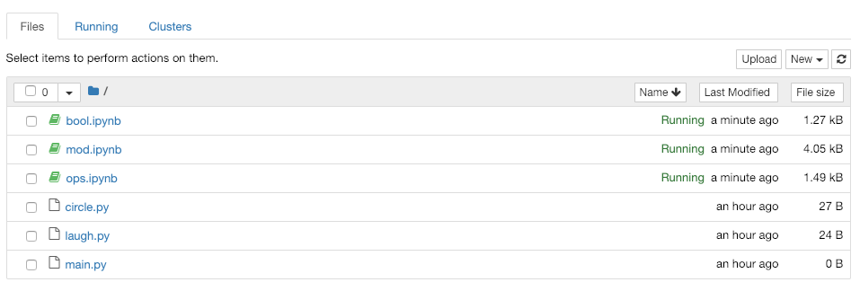

You can now click on any of the three notebooks you’ve downloaded to view the contents. The first thing you’ll want to do after opening it is click `Kernel` > `Restart & Run All` so you can see the outputs. The exercises you should do with each notebook are described below.

### Boolean Logic

Open and run the `bool.ipynb` notebook. There will be six cells, with outputs `True`, `False`, `False`, `True`, `False`, and `True`. Take moment to review each cell and think about why the output is either True or False. Review the lecture slides or ask your TA if any of these are surprising to you.

There are different ways to get `True` or `False` in Python. One way is to directly type those words explicitly, as we already have.

The more common way is to use comparison operators to make claims that are either True or False. For example `1+1 == 2` is True, whereas `-2 > 1` is False.

Your job is to edit the notebook and replace each True or False with a Python expression (of your own choosing) that has the same truth value. For example, the last expression says `True or False`, so I might edit that to instead be `1+1 == 2 or -2 > 1`. You should get creative, but try to use each of the following comparison examples at least once: `==`, `!=`, `<`, `<=`, `>`, and `>=`.

After each change, rerun the cell and make sure that your modification didn’t change the result. For example, that last cell was originally `True`, and I’ll verify it is still so after I change the code to `1+1 == 2 or -2 > 1` and rerun it.

### Order of Operations

Open and run the `ops.ipynb` notebook. There will be six cells, each containing a simple Python expression involving two operators. Python has operator-precedence rules to determine which of the two operators to execute first.

Of course, the Python programmer (you!) can add parentheses to change the order in which the operators are executed, thereby changing the result. Your job is to add parentheses in each case to get desired result. For example, in the first cell, `3 ** 4 - 1` evaluates to 80, but you should change it to be `3 ** (4 - 1)`, thereby getting 27.

### Modular Arithmetic

What time does a clock show one hour after twelve o’clock? Not 13 o’clock (that doesn’t exist) – instead, it wraps back around to 1 o’clock. This is a weird kind of arithmetic, where adding doesn’t always make a number larger.

This alternative arithmetic is called **modular arithmetic**, and we can use the modulo operator (`%`) in Python to perform modular addition. However, there’s a twist with respect to the clock: in CS, we count from 0, so if we were to have a **CS clock**, it would go from 0 o’clock to 11 o’clock (instead of from 1 o’clock to 12 o’clock).

Open and run the `mod.ipynb` notebook. You’ll see many cells of the form `X % 12`. This computation is answering the question: *if we start at 0 o’clock and wait `X` hours, what time is it?* The `% 12` part means time wraps around at 12 o’clock, meaning that there is no 12 o’clock, just 0 o’clock again (remember we have a CS clock that goes from 0 to 11 o’clock).

Try writing some expressions to answer the following questions regarding a CS clock:

- what time will it be 6 hours after 9 o’clock? (run `(9 + 6) % 12` in a cell to find the answer, which is 3 o’clock)
- what time was 2 hours before 1 o’clock? (run `(1 - 2) % 12` in a cell to find the answer, which is 11 o’clock)
- what time was 4 hours before 2 o’clock?
- what will it be 12 hours after 6 o’clock?
- what will it be 13 hours after 6 o’clock?
- what will it be 24 hours after 6 o’clock?
- what will it be 25 hours after 6 o’clock?